# Zillow Data Analyst Challenge

**By Luke Genung Date: 7/24/20**

This is a mock take-home data challenge that we could imagine for a company like Zillow.

As a disclaimer, I have never interviewed at Zillow or its competitors (like Trulia, Redfin, etc.). I do not know about their actual hiring practices.

## The Challenge

The Zillow App sends what are called “To-Do’s” (tasks in the data model) to users (buyers, sellers, real estate agents, transaction coordinators) asking for information - think TurboTax, but for escrow. There are various types of To-Do’s, and when users complete them in the app, it generates efficiency gains from an operational standpoint as it is not necessary to chase the customer down for the information. That is why “To-Do completion %” is one of the most important metrics, and the company is constantly looking for areas to improve these efficiencies.

## The Task

Extract and analyze the data provided in the accompanying Redshift database, and present the following:

- Key questions going into the exercise
- Insights and conclusions drawn from analyzing the data
- Recommendations on areas of opportunity to increase “To-Do completion %” for each of the user and/or To-Do types
- Areas of exploration that you would suggest doing as a next step / to dig in and further solidify your recommendations
- Executive Summary of the exercise. Format of the above output is your choice.

Include everything used to complete the task. This may include SQL scripts, Python code, visualizations, or other outputs.

## Overview

- The Zillow app sends "To-Do's" to users asking for information regarding properties and rentals
- There are various types of To Do's that generate efficiency gains from an operational standpoint
- To-Do completion % is a key metric, since Zillow is constantly looking for areas to improve these efficiencies

## Key Questions

- What levers can we pull to increase To-Do Completion %?
- Task types:
  - What improvements can be made to increase To-Do Completion for each task type?
  - What task types have the lowest & highest completion?
- Users & roles:
  - What can improvements can be made to increase To-Do Completion for each user segement / role?
  - What roles have the lowest & highest completion %?
  - What calls-to-action can we give users to increase their To-Do Completion %?

## Assumptions

# Analysis

### Total To-Do Completion %

To get a sense of the data, we can start by looking at the Total To-Do Completion % and the Monthly To-Do Completion % --

```python
import sqlite3
import pandas as pd
import matplotlib
import matplotlib.pyplot as plt

## IMPORTANT: UPDATE TO LOCAL FILEPATH ##
# Create the sql connection
conn = sqlite3.connect(r'/Users/luke/Downloads/data_analyst_challenge_data.sqlite')

# Count of tasks by completion status
task_counts = pd.read_sql_query(
    """
    SELECT
        CASE WHEN status = 'Completed' THEN 'Complete'
            WHEN status = 'Completed by Peer' THEN 'Complete'
            ELSE 'Incomplete'
        END AS 'status_type',
        COUNT(*) AS task_count,
        ROUND(COUNT(*) * 100.0 / SUM(COUNT(*)) OVER(), 1) || '%' AS percent_of_tasks
    FROM tasks
    WHERE tasks.name NOT LIKE '%test%'
    GROUP BY status_type
    """, conn
)

task_counts
```

|  | status_type | task_count | percent_of_tasks |
| --- | --- | --- | --- |
| 0 | Complete | 26138 | 71.1% |
| 1 | Incomplete | 10628 | 28.9% |

### Monthly To-Do Completion %

```python
# Task completion % by month
task_completion_by_month = pd.read_sql_query(
    """
    WITH complete_tasks AS (
        SELECT DISTINCT
            strftime("%Y-%m", datetime(completed, 'unixepoch', 'localtime')) AS completed_month,
            task_id AS comp_task_id
        FROM tasks
        WHERE (status = 'Completed' OR status = 'Completed by Peer')
        AND name NOT LIKE '%test%'
    ),

    due_tasks AS (
        SELECT DISTINCT
            strftime('%Y-%m', datetime(due_date, 'unixepoch', 'localtime')) AS due_month,
            task_id AS due_task_id
        FROM tasks
        WHERE name NOT LIKE '%test%'
    )

    SELECT
        due_month,
        COUNT(comp_task_id) AS num_complete_tasks,
        COUNT(due_task_id) AS num_due_tasks,
        ROUND(COUNT(comp_task_id) * 100.0 / COUNT(due_task_id), 1) AS task_complete_percent
    FROM due_tasks
    LEFT JOIN complete_tasks ON due_tasks.due_task_id = complete_tasks.comp_task_id
    GROUP BY due_month
    ORDER BY due_month
    """, conn
)

# Show running 13 months
task_completion_by_month['mom_percent_change'] = task_completion_by_month.task_complete_percent.diff()
task_completion_by_month['yoy_percent_change'] = task_completion_by_month.task_complete_percent.diff(12)
task_completion_by_month.tail(13).transpose()
```

|  | 13 | 14 | 15 | 16 | 17 | 18 | 19 | 20 | 21 | 22 | 23 | 24 | 25 |
| --- | --- | --- | --- | --- | --- | --- | --- | --- | --- | --- | --- | --- | --- |
| due_month | 2019-07 | 2019-08 | 2019-09 | 2019-10 | 2019-11 | 2019-12 | 2020-01 | 2020-02 | 2020-03 | 2020-04 | 2020-05 | 2020-06 | 2020-07 |
| num_complete_tasks | 1508 | 1743 | 1313 | 1287 | 1103 | 1028 | 1547 | 1981 | 3026 | 2563 | 4298 | 854 | 4 |
| num_due_tasks | 2109 | 2538 | 1876 | 1816 | 1630 | 1401 | 2193 | 2564 | 3990 | 3191 | 5313 | 1504 | 4 |
| task_complete_percent | 71.5 | 68.7 | 70 | 70.9 | 67.7 | 73.4 | 70.5 | 77.3 | 75.8 | 80.3 | 80.9 | 56.8 | 100 |
| mom_percent_change | 6.7 | -2.8 | 1.3 | 0.9 | -3.2 | 5.7 | -2.9 | 6.8 | -1.5 | 4.5 | 0.6 | -24.1 | 43.2 |
| yoy_percent_change | -28.5 | 68.7 | 51.9 | 54.2 | 25.4 | 20.6 | 18.7 | 13.2 | 10.8 | 8.4 | 19.4 | -8 | 28.5 |

### Plot - Monthly To-Do Completion %

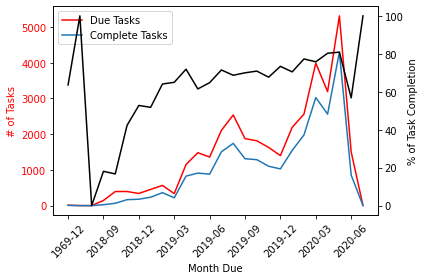

```python
# Task completion % by month
task_completion_by_month = pd.read_sql_query(
    """
    WITH complete_tasks AS (
        SELECT DISTINCT
            strftime("%Y-%m", datetime(completed, 'unixepoch', 'localtime')) AS completed_month,
            task_id AS comp_task_id
        FROM tasks
        WHERE (status = 'Completed' OR status = 'Completed by Peer')
        AND name NOT LIKE '%test%'
    ),

    due_tasks AS (
        SELECT DISTINCT
            strftime('%Y-%m', datetime(due_date, 'unixepoch', 'localtime')) AS due_month,
            task_id AS due_task_id
        FROM tasks
        WHERE name NOT LIKE '%test%'
    )

    SELECT
        due_month,
        COUNT(comp_task_id) AS num_complete_tasks,
        COUNT(due_task_id) AS num_due_tasks,
        ROUND(COUNT(comp_task_id) * 100.0 / COUNT(due_task_id), 1) AS task_complete_percent
    FROM due_tasks
    LEFT JOIN complete_tasks ON due_tasks.due_task_id = complete_tasks.comp_task_id
    GROUP BY due_month
    ORDER BY due_month
    """, conn
)

# Plot monthly task count and % completion
x = task_completion_by_month.due_month
y1a = task_completion_by_month.num_due_tasks
y1b = task_completion_by_month.num_complete_tasks
y2 = task_completion_by_month.task_complete_percent

fig, ax1 = plt.subplots()

# Format and plot primary x-y axes
color = 'red'
ax1.set_xlabel('Month Due')
ax1.set_ylabel('# of Tasks', color=color)
ax1.plot(x, y1a, color=color, label='Due Tasks')
ax1.plot(x, y1b, label='Complete Tasks')
ax1.tick_params(axis='y', labelcolor=color)
plt.legend()

# Format x ticks
ax1.set_xticks([tick for tick in ax1.get_xticks() if tick % 3 == 0])
plt.setp(ax1.xaxis.get_majorticklabels(), rotation=45)

# Create secondary y-axis
ax2 = ax1.twinx()

color = 'black'
ax2.set_ylabel('% of Task Completion', color=color)
ax2.plot(y2, color=color)
ax2.tick_params(axis='y', labelcolor=color)

fig.tight_layout()
plt.show()
```

## Total Summary

### Overall, To-Do's are being completed at a high rate, reaching up to 81% in 2020 YTD.

1. There is much to be proud of with To-Do Completion % showing strong monthly growth
2. However, there was a 24% drop in To-Do Completion in the last month (June 2020)
3. I recommend that we do a root-cause analysis to identify what caused this drop and understand what we can do to resolve

## Task Analysis

Next, we can look at performance of Total To-Do Completion and Monthly To-Do Completion by individual task types --

### To-Do Completion % by Priority

```python
# Task completion % by PRIORITY
task_completion_by_type = pd.read_sql_query(
    """
    WITH complete_tasks AS (
        SELECT DISTINCT
            task_id AS comp_task_id
        FROM tasks
        WHERE (status = 'Completed' OR status = 'Completed by Peer')
        AND name NOT LIKE '%test%'
    )

    SELECT
        priority,
        COUNT(comp_task_id) AS num_complete_tasks,
        COUNT(*)-COUNT(comp_task_id) AS num_incomplete_tasks,
        COUNT(*) AS num_tasks,
        ROUND(COUNT(comp_task_id) * 100.0 / COUNT(*), 1) AS task_complete_percent
    FROM tasks
    LEFT JOIN complete_tasks ON tasks.task_id = complete_tasks.comp_task_id
    WHERE name NOT LIKE '%test%'
    GROUP BY 1
    ORDER BY task_complete_percent DESC
    """, conn
)

task_completion_by_type
```

|  | priority | num_complete_tasks | num_incomplete_tasks | num_tasks | task_complete_percent |
| --- | --- | --- | --- | --- | --- |
| 0 | false | 17824 | 5146 | 22970 | 77.6 |
| 1 | true | 8314 | 5482 | 13796 | 60.3 |

### Plot - Monthly To-Do Completion % by Priority

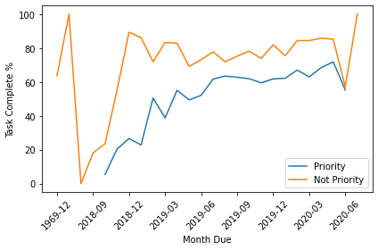

```python
# Monthly task completion % by PRIORITY
task_completion_by_priority = pd.read_sql_query(
    """
    WITH complete_tasks AS (
        SELECT DISTINCT
            strftime("%Y-%m", datetime(completed, 'unixepoch', 'localtime')) AS completed_month,
            task_id AS comp_task_id
        FROM tasks
        WHERE (status = 'Completed' OR status = 'Completed by Peer')
        AND name NOT LIKE '%test%'
    ),

    due_tasks AS (
        SELECT DISTINCT
            strftime('%Y-%m', datetime(due_date, 'unixepoch', 'localtime')) AS due_month,
            task_id AS due_task_id,
            priority
        FROM tasks
        WHERE name NOT LIKE '%test%'
    ),

    monthly_complete_percent AS (
        SELECT
            due_month,
            priority,
            COUNT(comp_task_id) AS num_complete_tasks,
            COUNT(due_task_id) AS num_due_tasks,
            ROUND(COUNT(comp_task_id) * 100.0 / COUNT(due_task_id), 1) AS task_complete_percent
        FROM due_tasks
        LEFT JOIN complete_tasks ON due_tasks.due_task_id = complete_tasks.comp_task_id
        GROUP BY 1,2
        ORDER BY due_month
    )

    -- Pivot the results
    SELECT
        due_month,
        SUM(CASE WHEN priority = 'false' THEN task_complete_percent END) AS not_priority_percent,
        SUM(CASE WHEN priority = 'true' THEN task_complete_percent END) AS priority_percent
    FROM monthly_complete_percent
    GROUP BY due_month
    """, conn
)

# Plot monthly % completion
x = task_completion_by_priority.due_month
y1 = task_completion_by_priority.priority_percent
y2 = task_completion_by_priority.not_priority_percent

fig, ax1 = plt.subplots()

# Format and plot x-y axes
ax1.set_xlabel('Month Due')
ax1.set_ylabel('Task Complete %')
ax1.plot(x, y1, label='Priority')
ax1.plot(x, y2, label='Not Priority')
ax1.tick_params(axis='y')

# Format x ticks
ax1.set_xticks([tick for tick in ax1.get_xticks() if tick % 3 == 0])
plt.setp(ax1.xaxis.get_majorticklabels(), rotation=45)

plt.legend()
fig.tight_layout()
plt.show()
```

## Task Summary

### Non-priority tasks are completed at a much higher rate than priority tasks (78% vs. 60%).

1. Overall, completion % of non-priority tasks outperforms priority tasks.
2. However, priority task completion is showing strong monthly growth - while non-priority task completion % has remained largely flat.
3. **To increase task completion by type, we should look at ways to improve completion of priority tasks --**

### Top & Bottom Performers by Task Type

Most completed tasks by **non-priority and type**

```
- Non-priority e-sign 89%
- Non-priority Questions 76%
- Non-priority Upload 68%
- Non-priority EMD 67%
- Non-priority Schedule Notary 65%
- Non-priority Acknowledge 63%
```

Least completed tasks by **priority and type**

```
- Priority Questions 54%
- Priority e-sign 54%
- Priority Acknowledge 45%
- Priority Upload 45%
- Priority Schedule Notary 25%
- Priority EMD 16%
```

See query below --

```python
# Task completion % by PRIORITY and TYPE
task_completion_by_type = pd.read_sql_query(
    """
    WITH complete_tasks AS (
        SELECT
            priority,
            type,
            COUNT(*) AS num_complete_tasks
        FROM tasks
        WHERE (status = 'Completed' OR status = 'Completed by Peer')
        AND name NOT LIKE '%test%'
        AND type <> 'NA'
        GROUP BY 1,2
    ),

    total_tasks AS (
        SELECT
            priority,
            type,
            COUNT(*) AS num_total_tasks
        FROM tasks
        WHERE name NOT LIKE '%test%'
        AND type <> 'NA'
        GROUP BY 1,2
    )

    SELECT
        total_tasks.priority,
        total_tasks.type,
        num_complete_tasks,
        num_total_tasks - num_complete_tasks AS num_incomplete_tasks,
        num_total_tasks,
        ROUND(num_complete_tasks * 100.0 / num_total_tasks, 1) AS task_complete_percent
    FROM total_tasks
    LEFT JOIN complete_tasks ON total_tasks.priority = complete_tasks.priority
    AND total_tasks.type = complete_tasks.type
    ORDER BY total_tasks.priority, task_complete_percent DESC
    """, conn
)

task_completion_by_type
```

|  | priority | type | num_complete_tasks | num_incomplete_tasks | num_total_tasks | task_complete_percent |
| --- | --- | --- | --- | --- | --- | --- |
| 0 | false | e-sign | 736 | 93 | 829 | 88.8 |
| 1 | false | Questions | 1415 | 445 | 1860 | 76.1 |
| 2 | false | Upload | 139 | 67 | 206 | 67.5 |
| 3 | false | EMD | 214 | 104 | 318 | 67.3 |
| 4 | false | Schedule Notary | 239 | 130 | 369 | 64.8 |
| 5 | false | Acknowledge | 1317 | 759 | 2076 | 63.4 |
| 6 | true | Questions | 714 | 614 | 1328 | 53.8 |
| 7 | true | e-sign | 214 | 186 | 400 | 53.5 |
| 8 | true | Acknowledge | 627 | 778 | 1405 | 44.6 |
| 9 | true | Upload | 122 | 152 | 274 | 44.5 |
| 10 | true | Schedule Notary | 18 | 54 | 72 | 25.0 |
| 11 | true | EMD | 13 | 68 | 81 | 16.0 |

## User Analysis

Lastly, we can look at performance of Total To-Do Completion % and the Monthly To-Do Completion % by user segements and roles --

### To-Do Completion % by Role

```python
# Task completion % by ROLE
task_stats = pd.read_sql_query(
    """
    WITH complete_tasks AS (
        SELECT DISTINCT
            task_id AS comp_task_id
        FROM tasks
        WHERE (status = 'Completed' OR status = 'Completed by Peer')
        AND name NOT LIKE '%test%'
    )

    SELECT
        role,
        COUNT(comp_task_id) AS num_complete_tasks,
        COUNT(*)-COUNT(comp_task_id) AS num_incomplete_tasks,
        COUNT(*) AS num_tasks,
        ROUND(COUNT(comp_task_id) * 100.0 / COUNT(*), 1) AS task_complete_percent
    FROM tasks
    LEFT JOIN complete_tasks ON tasks.task_id = complete_tasks.comp_task_id
    LEFT JOIN users ON tasks.assignee = users.id
    LEFT JOIN roles ON users.id = roles.user_id
    WHERE name NOT LIKE '%test%'
    AND role <> 'NA'
    AND role <> 'x'
    GROUP BY 1
    """, conn
)

task_stats
```

|  | role | num_complete_tasks | num_incomplete_tasks | num_tasks | task_complete_percent |
| --- | --- | --- | --- | --- | --- |
| 0 | Agent | 52693 | 49138 | 101831 | 51.7 |
| 1 | Buyer | 8488 | 2322 | 10810 | 78.5 |
| 2 | Seller | 9609 | 1867 | 11476 | 83.7 |

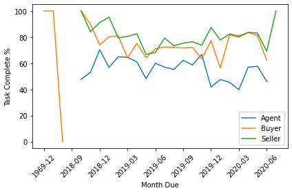

```python
# Monthly task completion % by ROLE
task_completion_by_priority = pd.read_sql_query(
    """
    WITH complete_tasks AS (
        SELECT DISTINCT
            strftime("%Y-%m", datetime(completed, 'unixepoch', 'localtime')) AS completed_month,
            task_id AS comp_task_id
        FROM tasks
        WHERE (status = 'Completed' OR status = 'Completed by Peer')
        AND name NOT LIKE '%test%'
    ),

    due_tasks AS (
        SELECT DISTINCT
            strftime('%Y-%m', datetime(due_date, 'unixepoch', 'localtime')) AS due_month,
            task_id AS due_task_id,
            assignee
        FROM tasks
        WHERE name NOT LIKE '%test%'
    ),

    monthly_complete_percent AS (
        SELECT
            due_month,
            role,
            COUNT(comp_task_id) AS num_complete_tasks,
            COUNT(due_task_id) AS num_due_tasks,
            ROUND(COUNT(comp_task_id) * 100.0 / COUNT(due_task_id), 1) AS task_complete_percent
        FROM due_tasks
        LEFT JOIN complete_tasks ON due_tasks.due_task_id = complete_tasks.comp_task_id
        LEFT JOIN roles ON due_tasks.assignee = roles.user_id
        GROUP BY 1,2
        ORDER BY due_month
    )

    -- Pivot the results
    SELECT
        due_month,
        SUM(CASE WHEN role = 'Agent' THEN task_complete_percent END) AS agent_percent,
        SUM(CASE WHEN role = 'Buyer' THEN task_complete_percent END) AS buyer_percent,
        SUM(CASE WHEN role = 'Seller' THEN task_complete_percent END) AS seller_percent
    FROM monthly_complete_percent
    GROUP BY due_month
    """, conn
)

# Plot monthly % completion
x = task_completion_by_priority.due_month
y1 = task_completion_by_priority.agent_percent
y2 = task_completion_by_priority.buyer_percent
y3 = task_completion_by_priority.seller_percent

fig, ax1 = plt.subplots()

# Format and plot x-y axes
ax1.set_xlabel('Month Due')
ax1.set_ylabel('Task Complete %')
ax1.plot(x, y1, label='Agent')
ax1.plot(x, y2, label='Buyer')
ax1.plot(x, y3, label='Seller')
ax1.tick_params(axis='y')

# Format x ticks
ax1.set_xticks([tick for tick in ax1.get_xticks() if tick % 3 == 0])
plt.setp(ax1.xaxis.get_majorticklabels(), rotation=45)

plt.legend()
fig.tight_layout()
plt.show()
```

## User Summary

### Buyers and Sellers complete To-Do's at high rate (79% & 84%), though Agents are lagging behind (52%).

1. Buyers and Sellers are completing their To-Do's at a consistent rate month-over-month
2. However, To-Do Completion for Agents may be declining in recent months

## Suggested Areas of Future Exploration

### Additional analysis

Additional analysis could improve & solidify the present analysis & recommendations.

- What additional metrics could be important to drive task completion %?
  - Example: Rate (velocity) of task completion
- Which tasks take the most & least time to complete?
- How can we decrease time to complete long tasks?
- Which user segments / roles take the most & least time to complete tasks?

### Data quality

It is advisable to address missing user & task data to improve the quality of the current & future analyses.

### Other questions

- What are the most & least valuable transactions?
- How can we improve task completion % for the most valuable transactions?